# ATAC-seq in Bioconductor exercises

Tom Carroll

In todays session we will work with some of the ATAC-seq data of T-regulatory cells from Christina Leslie’s lab.

FQ files can be found can be found [here for read1](https://www.encodeproject.org/files/ENCFF175VOD/@@download/ENCFF175VOD.fastq.gz) and [here for read2](https://www.encodeproject.org/files/ENCFF447BGX/@@download/ENCFF447BGX.fastq.gz).

We will also work with the aligned data as a BAM file [which can be found here.](https://www.encodeproject.org/files/ENCFF053CGD/@@download/ENCFF053CGD.bam)

## ATAC-seq preprocessing.

1. Read in a random 10000 reads from read 1 and read 2 and produce two boxplots of quality scores over cycles.

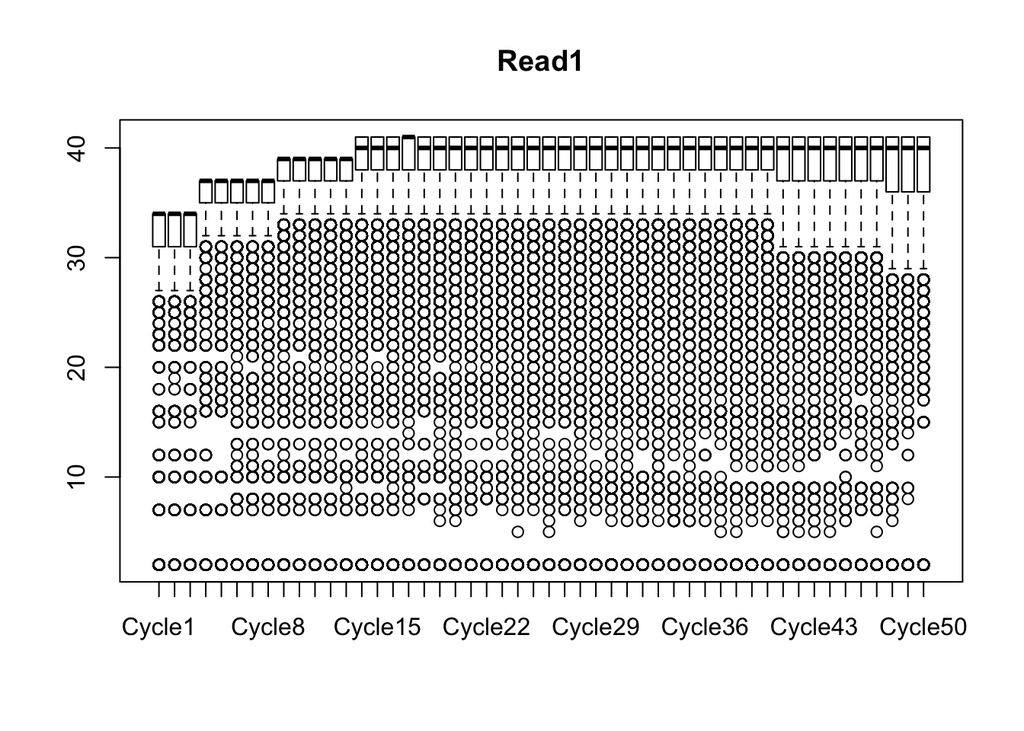

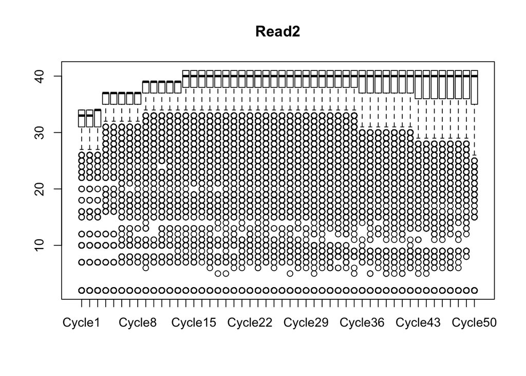

2. Create a line plot of Base frequencies across cycles for read1 and read2.

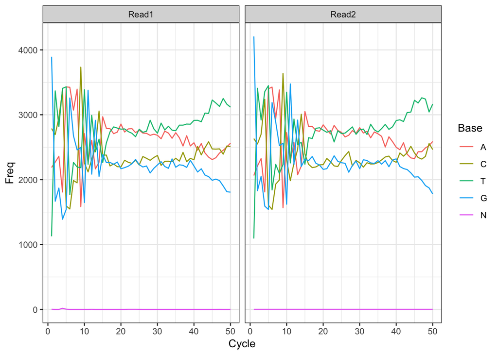

3. **Optional** Align the reads in hg38 genome and create sorted, indexed BAM file.
4. Using the BAM file retrieved from Encode, plot the fragment length distribution for reads chromosome 10 using ggplot2.

```
##       /Users/tcarroll/Downloads/ENCFF053CGD.bam
## "/Users/tcarroll/Downloads/ENCFF053CGD.bam.bai"
```

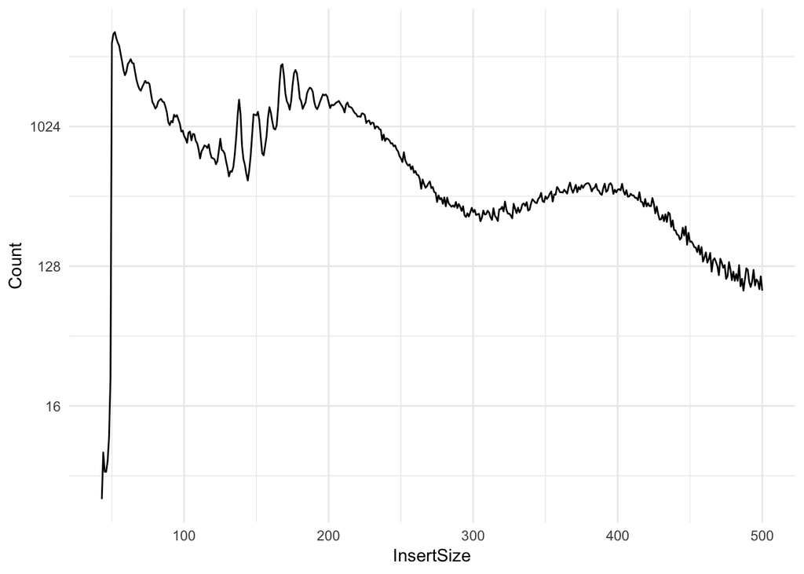

5. Create a barplot of number of fragments within Greenleafs’ defined ranges – nucleosome free (< 100bp), mono-nucleosome (180bp-247bp) and di-nucleosome (315-437)

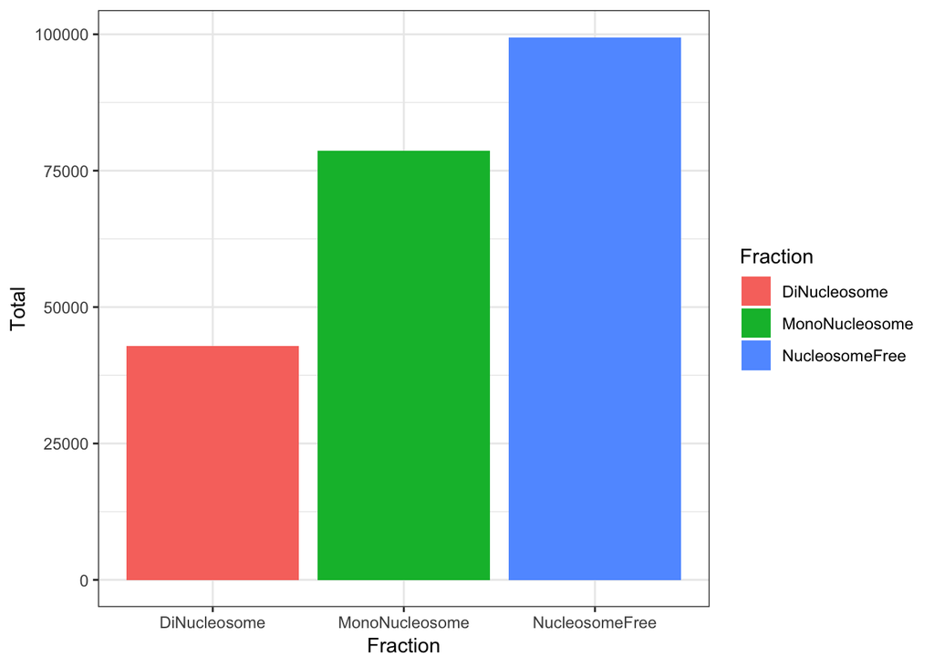

6 Create a bigwig for the nucleosome free (< 100bp), mono-nucleosome (180bp-247bp) and di-nucleosome (315-437) fractions and visualise in IGV.

[figure not shown]